# Module 135

#### Hemi-module gene counts:

451 probesets in hemi-module A.  
51 probesets in hemi-module B.  
Note: While the mapping of probesets to genes is usually one-to-one, some genes are targeted by multiple probesets, some probesets target multiple genes, and some probesets do not target any genes (i.e., the region of the genome they match is no longer considered genic).

#### Contrast SVE:

Signed variance explained (SVE) provides an indication of how similar a set of fold changes are to a gene module’s weight vector. An SVE value of 0.3, for example, indicates that 30% of the variance explained by the entire module set is accounted for by the module in question. Shown here are the SVE values for this module across a compendium of fold changes (contrasts). Extreme SVE values (e.g., > 0.05) indicate that those contrasts specifically induce (orange dots) or specifically repress (blue dots) this module. Examining the experimental conditions being compared in such contrasts (see tables below the figure) may provide insight into the gene module’s function.

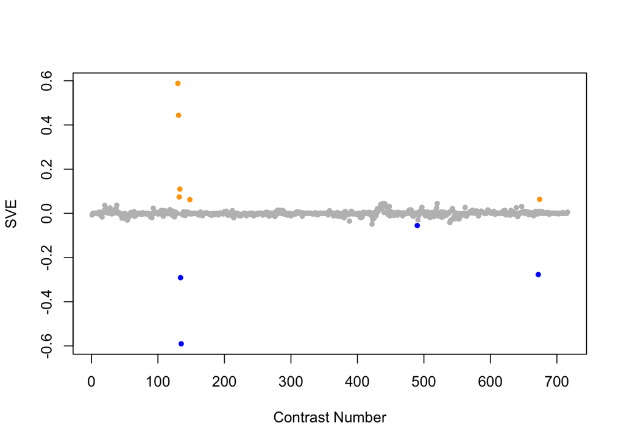

Positive SVE Contrasts:

|  | Contrast.Num | SVE | GEO.GSE | Cond.1 | Cond.2 | Mutation |
| --- | --- | --- | --- | --- | --- | --- |
| GSE52064.s4t1.vs.s3t1 | 130 | 0.59 | GSE52064 | lin-54;mes-4_1 | lin-54_1 | mes-4 |
| GSE52064.s2t1.vs.s3t1 | 131 | 0.44 | GSE52064 | mes-4_1 | lin-54_1 | mes-4 vs. lin-54 |
| GSE52064.s2t1.vs.s4t1 | 133 | 0.11 | GSE52064 | mes-4_1 | lin-54;mes-4_1 | lin-54 |
| GSE52064.s1t1.vs.s3t1 | 132 | 0.07 | GSE52064 | wildtype_1 | lin-54_1 | lin-54 |
| GSE14640C.s1t1.vs.s0t1 | 674 | 0.06 | GSE14640 | XX_SDC2Y93R-P-022208_A | XX_WT-P_081407_A |  |
| GSE48347.s2t1.vs.s0t1 | 148 | 0.06 | GSE48347 | sdc2_embryo_rep1 | WT_embryo_rep1 | sdc-2 |

Negative SVE Contrasts:

|  | Contrast.Num | SVE | GEO.GSE | Cond.1 | Cond.2 | Mutation |
| --- | --- | --- | --- | --- | --- | --- |
| GSE52064.s1t1.vs.s2t1 | 135 | -0.59 | GSE52064 | wildtype_1 | mes-4_1 | mes-4 |
| GSE52064.s1t1.vs.s4t1 | 134 | -0.29 | GSE52064 | wildtype_1 | lin-54;mes-4_1 | lin-54;mes-4 |
| GSE14640A.s1t1.vs.s0t1 | 672 | -0.28 | GSE14640 | XO_TY2222-E_080307_A | XX_WT-E_080307_A |  |
| GSE23528B.s1t4.vs.s1t1 | 490 | -0.06 | GSE23528 | Adult at T38 in CC, time-series experiment 3 | Adult at T26 in CC, time-series experiment 3 |  |
| GSE28494.s1t2.vs.s1t1 | 422 | -0.05 | GSE28494 | lin-54(n3423) dissected germline 1 | lin-54(n2990) embryo 1 |  |

$~$

#### Contrast SVE, Up-Regulated Genes Only:

Calculating SVE for up-regulated and down-regulated genes separately may be more informative in many cases than projecting the up- and down- gene sets together. This is due to the fact that the weight distribution of many modules is highly skewed, indicating that only one of the hemi-modules may be biologically meaningful (i.e., a set of genes are strongly correlated by only a few genes (or none) are strongly anti-correlated to that set.)

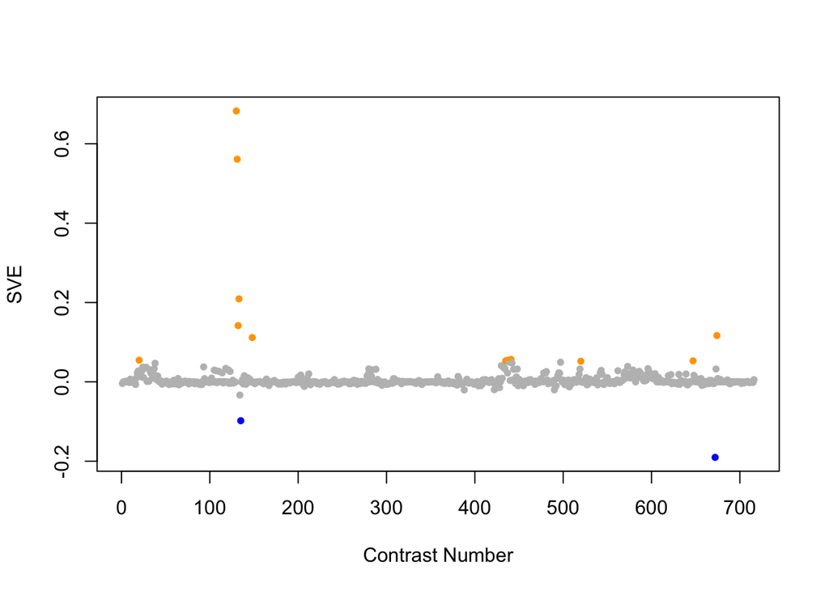

Positive SVE Contrasts:

|  | Contrast.Num | SVE | GEO.GSE | Cond.1 | Cond.2 | Mutation |
| --- | --- | --- | --- | --- | --- | --- |
| GSE52064.s4t1.vs.s3t1 | 130 | 0.68 | GSE52064 | lin-54;mes-4_1 | lin-54_1 | mes-4 |
| GSE52064.s2t1.vs.s3t1 | 131 | 0.56 | GSE52064 | mes-4_1 | lin-54_1 | mes-4 vs. lin-54 |
| GSE52064.s2t1.vs.s4t1 | 133 | 0.21 | GSE52064 | mes-4_1 | lin-54;mes-4_1 | lin-54 |
| GSE52064.s1t1.vs.s3t1 | 132 | 0.14 | GSE52064 | wildtype_1 | lin-54_1 | lin-54 |
| GSE14640C.s1t1.vs.s0t1 | 674 | 0.12 | GSE14640 | XX_SDC2Y93R-P-022208_A | XX_WT-P_081407_A |  |
| GSE48347.s2t1.vs.s0t1 | 148 | 0.11 | GSE48347 | sdc2_embryo_rep1 | WT_embryo_rep1 | sdc-2 |
| GSE27677B.s1t8.vs.s1t1 | 441 | 0.06 | GSE27677 | N2, Fast 36 h, rep 1 | N2, Fed 0 h, rep 1 |  |
| GSE27677B.s1t6.vs.s1t1 | 438 | 0.05 | GSE27677 | N2, Fast 18 h, rep 1 | N2, Fed 0 h, rep 1 |  |
| GSE9665.s9t1.vs.s0t1 | 20 | 0.05 | GSE9665 | mex-3 scrt-1 143 A | mex-3 143 A | scrt-1 |
| GSE27677B.s1t9.vs.s0t9 | 436 | 0.05 | GSE27677 | N2, Fast 48 h, rep 1 | N2, Fed 48 h, rep 1 |  |
| GSE27677B.s1t7.vs.s0t7 | 435 | 0.05 | GSE27677 | N2, Fast 24 h, rep 1 | N2, Fed 24 h, rep 1 |  |
| GSE16753.s2t1.vs.s0t1 | 647 | 0.05 | GSE16753 | fer-1 (hc1ts) mutant young adult biological rep 1 | Wild-type young adult biological rep 3 | fer-1 |
| GSE2180.s4t7.vs.s3t7 | 520 | 0.05 | GSE2180 | pp101-1 | p101-2 | pal-1(RNAi) |

Negative SVE Contrasts:

|  | Contrast.Num | SVE | GEO.GSE | Cond.1 | Cond.2 | Mutation |
| --- | --- | --- | --- | --- | --- | --- |
| GSE14640A.s1t1.vs.s0t1 | 672 | -0.19 | GSE14640 | XO_TY2222-E_080307_A | XX_WT-E_080307_A |  |
| GSE52064.s1t1.vs.s2t1 | 135 | -0.10 | GSE52064 | wildtype_1 | mes-4_1 | mes-4 |
| GSE52064.s1t1.vs.s4t1 | 134 | -0.03 | GSE52064 | wildtype_1 | lin-54;mes-4_1 | lin-54;mes-4 |
| GSE32949.s1t1.vs.s0t1 | 388 | -0.02 | GSE32949 | C. elegans exposed to space condition, technical rep1 | C. elegans ground control, technical rep1 |  |
| GSE23528B.s1t4.vs.s1t1 | 490 | -0.02 | GSE23528 | Adult at T38 in CC, time-series experiment 3 | Adult at T26 in CC, time-series experiment 3 |  |

$~$

#### Contrast SVE, Down-Regulated Genes Only:

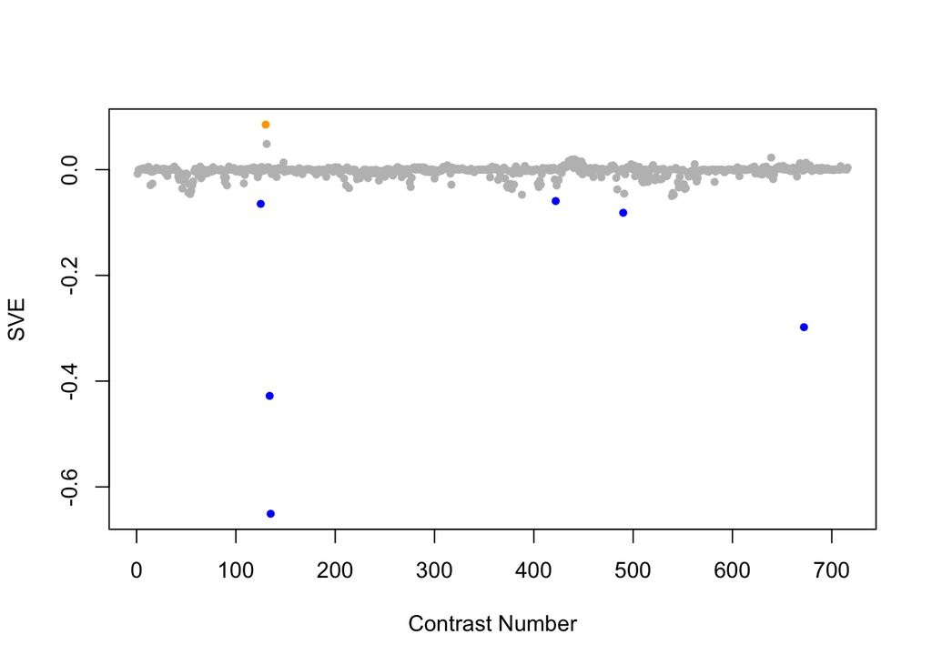

Positive SVE Contrasts:

|  | Contrast.Num | SVE | GEO.GSE | Cond.1 | Cond.2 | Mutation |
| --- | --- | --- | --- | --- | --- | --- |
| GSE52064.s4t1.vs.s3t1 | 130 | 0.09 | GSE52064 | lin-54;mes-4_1 | lin-54_1 | mes-4 |
| GSE52064.s2t1.vs.s3t1 | 131 | 0.05 | GSE52064 | mes-4_1 | lin-54_1 | mes-4 vs. lin-54 |
| GSE18132.s1t1.vs.s0t1 | 639 | 0.02 | GSE18132 | Ogt starved L1, biological replicate 1 | WT Starved L1, biological rep1 | ogt-1 |
| GSE27677B.s1t8.vs.s1t1 | 441 | 0.02 | GSE27677 | N2, Fast 36 h, rep 1 | N2, Fed 0 h, rep 1 |  |
| GSE27677B.s1t6.vs.s1t1 | 438 | 0.02 | GSE27677 | N2, Fast 18 h, rep 1 | N2, Fed 0 h, rep 1 |  |

Negative SVE Contrasts:

|  | Contrast.Num | SVE | GEO.GSE | Cond.1 | Cond.2 | Mutation |
| --- | --- | --- | --- | --- | --- | --- |
| GSE52064.s1t1.vs.s2t1 | 135 | -0.65 | GSE52064 | wildtype_1 | mes-4_1 | mes-4 |
| GSE52064.s1t1.vs.s4t1 | 134 | -0.43 | GSE52064 | wildtype_1 | lin-54;mes-4_1 | lin-54;mes-4 |
| GSE14640A.s1t1.vs.s0t1 | 672 | -0.30 | GSE14640 | XO_TY2222-E_080307_A | XX_WT-E_080307_A |  |
| GSE23528B.s1t4.vs.s1t1 | 490 | -0.08 | GSE23528 | Adult at T38 in CC, time-series experiment 3 | Adult at T26 in CC, time-series experiment 3 |  |
| GSE54024.s1t1.vs.s2t1 | 125 | -0.06 | GSE54024 | Wild type young adults, biological rep 1 | Wild type young adults treated with 0.1mM paraquat, biological rep 1 |  |
| GSE28494.s1t2.vs.s1t1 | 422 | -0.06 | GSE28494 | lin-54(n3423) dissected germline 1 | lin-54(n2990) embryo 1 |  |

$~$

$~$

#### GO Term Enrichment:

This analysis tests each hemi-module for enrichment of specific GO terms. Only gene-level annotations (e.g., as would be found on the gene’s page in Wormbase) are tested - the hierarchical structure of the GO ontology is not taken into account.

*Note: At least the top two most enriched terms from each GO domain (BP/MF/CC) are shown, even when not statistically significant.*

##### Enriched GO terms: Hemi-module A

| ID | GO.Term | GO Domain | Raw p-value | Adj p-value |
| --- | --- | --- | --- | --- |
| [GO_0016192](http://amigo.geneontology.org/amigo/term/GO:0016192) | vesicle-mediated transport | BP | 1.46e-10 | 5.33e-07 |
| [GO_0043547](http://amigo.geneontology.org/amigo/term/GO:0043547) | positive regulation of GTPase activity | BP | 4.94e-07 | 8.99e-04 |
| [GO_0030968](http://amigo.geneontology.org/amigo/term/GO:0030968) | endoplasmic reticulum unfolded protein response | BP | 7.02e-06 | 8.53e-03 |
| [GO_0006886](http://amigo.geneontology.org/amigo/term/GO:0006886) | intracellular protein transport | BP | 1.32e-05 | 1.20e-02 |
| [GO_0006888](http://amigo.geneontology.org/amigo/term/GO:0006888) | ER to Golgi vesicle-mediated transport | BP | 1.65e-05 | 1.20e-02 |
| [GO_0040027](http://amigo.geneontology.org/amigo/term/GO:0040027) | negative regulation of vulval development | BP | 1.97e-05 | 1.20e-02 |
| [GO_0015031](http://amigo.geneontology.org/amigo/term/GO:0015031) | protein transport | BP | 2.50e-05 | 1.27e-02 |
| [GO_0006099](http://amigo.geneontology.org/amigo/term/GO:0006099) | tricarboxylic acid cycle | BP | 2.80e-05 | 1.27e-02 |
| [GO_0006893](http://amigo.geneontology.org/amigo/term/GO:0006893) | Golgi to plasma membrane transport | BP | 3.73e-05 | 1.51e-02 |
| [GO_0042464](http://amigo.geneontology.org/amigo/term/GO:0042464) | dosage compensation by hypoactivation of X chromosome | BP | 6.11e-05 | 2.22e-02 |
| [GO_0016310](http://amigo.geneontology.org/amigo/term/GO:0016310) | phosphorylation | BP | 6.83e-05 | 2.26e-02 |
| [GO_0006890](http://amigo.geneontology.org/amigo/term/GO:0006890) | retrograde vesicle-mediated transport, Golgi to ER | BP | 8.90e-05 | 2.70e-02 |
| [GO_0042147](http://amigo.geneontology.org/amigo/term/GO:0042147) | retrograde transport, endosome to Golgi | BP | 1.15e-04 | 3.21e-02 |
| [GO_0046580](http://amigo.geneontology.org/amigo/term/GO:0046580) | negative regulation of Ras protein signal transduction | BP | 1.96e-04 | 5.11e-02 |
| [GO_0000266](http://amigo.geneontology.org/amigo/term/GO:0000266) | mitochondrial fission | BP | 2.60e-04 | 6.14e-02 |
| [GO_0006898](http://amigo.geneontology.org/amigo/term/GO:0006898) | receptor-mediated endocytosis | BP | 2.70e-04 | 6.14e-02 |
| [GO_0036498](http://amigo.geneontology.org/amigo/term/GO:0036498) | IRE1-mediated unfolded protein response | BP | 3.09e-04 | 6.62e-02 |
| [GO_0023014](http://amigo.geneontology.org/amigo/term/GO:0023014) | signal transduction by protein phosphorylation | BP | 3.36e-04 | 6.79e-02 |
| [GO_0007186](http://amigo.geneontology.org/amigo/term/GO:0007186) | G protein-coupled receptor signaling pathway | BP | 4.32e-04 | 8.14e-02 |
| [GO_0046579](http://amigo.geneontology.org/amigo/term/GO:0046579) | positive regulation of Ras protein signal transduction | BP | 4.47e-04 | 8.14e-02 |
| [GO_0006256](http://amigo.geneontology.org/amigo/term/GO:0006256) | UDP catabolic process | BP | 5.75e-04 | 9.52e-02 |
| [GO_0046712](http://amigo.geneontology.org/amigo/term/GO:0046712) | GDP catabolic process | BP | 5.75e-04 | 9.52e-02 |
| [GO_0046854](http://amigo.geneontology.org/amigo/term/GO:0046854) | phosphatidylinositol phosphorylation | BP | 6.06e-04 | 9.60e-02 |
| [GO_0005096](http://amigo.geneontology.org/amigo/term/GO:0005096) | GTPase activator activity | MF | 1.71e-07 | 3.49e-04 |
| [GO_0017137](http://amigo.geneontology.org/amigo/term/GO:0017137) | Rab GTPase binding | MF | 6.47e-07 | 6.61e-04 |
| [GO_0016301](http://amigo.geneontology.org/amigo/term/GO:0016301) | kinase activity | MF | 5.03e-05 | 3.43e-02 |
| [GO_0005783](http://amigo.geneontology.org/amigo/term/GO:0005783) | endoplasmic reticulum | CC | 1.54e-08 | 1.43e-05 |
| [GO_0005794](http://amigo.geneontology.org/amigo/term/GO:0005794) | Golgi apparatus | CC | 1.68e-05 | 7.81e-03 |
| [GO_0005737](http://amigo.geneontology.org/amigo/term/GO:0005737) | cytoplasm | CC | 1.28e-04 | 3.05e-02 |
| [GO_0032009](http://amigo.geneontology.org/amigo/term/GO:0032009) | early phagosome | CC | 1.32e-04 | 3.05e-02 |
| [GO_0030173](http://amigo.geneontology.org/amigo/term/GO:0030173) | integral component of Golgi membrane | CC | 1.65e-04 | 3.05e-02 |
| [GO_0030131](http://amigo.geneontology.org/amigo/term/GO:0030131) | clathrin adaptor complex | CC | 2.60e-04 | 3.58e-02 |
| [GO_0045335](http://amigo.geneontology.org/amigo/term/GO:0045335) | phagocytic vesicle | CC | 2.70e-04 | 3.58e-02 |
| [GO_0000138](http://amigo.geneontology.org/amigo/term/GO:0000138) | Golgi trans cisterna | CC | 4.47e-04 | 4.65e-02 |
| [GO_0005793](http://amigo.geneontology.org/amigo/term/GO:0005793) | endoplasmic reticulum-Golgi intermediate compartment | CC | 4.72e-04 | 4.65e-02 |
| [GO_0005789](http://amigo.geneontology.org/amigo/term/GO:0005789) | endoplasmic reticulum membrane | CC | 5.06e-04 | 4.65e-02 |
| [GO_0030122](http://amigo.geneontology.org/amigo/term/GO:0030122) | AP-2 adaptor complex | CC | 5.75e-04 | 4.65e-02 |
| [GO_0001891](http://amigo.geneontology.org/amigo/term/GO:0001891) | phagocytic cup | CC | 7.02e-04 | 4.65e-02 |
| [GO_0005797](http://amigo.geneontology.org/amigo/term/GO:0005797) | Golgi medial cisterna | CC | 7.02e-04 | 4.65e-02 |
| [GO_0005905](http://amigo.geneontology.org/amigo/term/GO:0005905) | clathrin-coated pit | CC | 7.02e-04 | 4.65e-02 |
| [GO_0016021](http://amigo.geneontology.org/amigo/term/GO:0016021) | integral component of membrane | CC | 1.00e-03 | 6.21e-02 |
| [GO_0012507](http://amigo.geneontology.org/amigo/term/GO:0012507) | ER to Golgi transport vesicle membrane | CC | 1.45e-03 | 8.42e-02 |

##### Enriched GO terms: Hemi-module B

| ID | GO.Term | GO Domain | Raw p-value | Adj p-value |
| --- | --- | --- | --- | --- |
| [GO_0006116](http://amigo.geneontology.org/amigo/term/GO:0006116) | NADH oxidation | BP | 3.65e-03 | 1.00e+00 |
| [GO_0006564](http://amigo.geneontology.org/amigo/term/GO:0006564) | L-serine biosynthetic process | BP | 3.65e-03 | 1.00e+00 |
| [GO_0003824](http://amigo.geneontology.org/amigo/term/GO:0003824) | catalytic activity | MF | 2.89e-04 | 5.91e-01 |
| [GO_0004647](http://amigo.geneontology.org/amigo/term/GO:0004647) | phosphoserine phosphatase activity | MF | 1.83e-03 | 1.00e+00 |
| [GO_0016507](http://amigo.geneontology.org/amigo/term/GO:0016507) | mitochondrial fatty acid beta-oxidation multienzyme complex | CC | 3.65e-03 | 1.00e+00 |
| [GO_0009331](http://amigo.geneontology.org/amigo/term/GO:0009331) | glycerol-3-phosphate dehydrogenase complex | CC | 7.29e-03 | 1.00e+00 |

$~$

$~$

#### Tissue Enrichment:

This analysis tests each hemi-module for enrichment of genes associated with anatomy terms. Negative enrichment scores indicate fewer hemi-module genes than expected by random chance were associated with the anatomy term in question.

##### Enriched tissues: Hemi-module A

| ID | Anatomy.Term | Definition | Raw p-value | Adj p-value |
| --- | --- | --- | --- | --- |
| [WBbt_0005374](https://wormbase.org/species/all/anatomy_term/WBbt:0005374) | anterior gonad arm | anterior lobe of the bi-lobbed hermaphrodite gonad. | 3.29e-17 | 8.01e-14 |
| [WBbt_0003681](https://wormbase.org/species/all/anatomy_term/WBbt:0003681) | pharynx | the feeding organ, a neuro-muscular pump in the head of the animal, used to ingest food, bacteria suspended in liquid, filter them out, grind them up and transport posteriorly into the instestine. | 3.50e-09 | 4.25e-06 |
| [WBbt_0005813](https://wormbase.org/species/all/anatomy_term/WBbt:0005813) | body wall musculature | Longitudinal bands of muscle cells surrounding animal body, with one band running in each quadrant of the body, regulated contraction and relaxation of these muscles cause locomotion. | 1.04e-07 | 8.47e-05 |
| [WBbt_0005451](https://wormbase.org/species/all/anatomy_term/WBbt:0005451) | pharyngeal muscle cell | type of cells that make up muscle layers in the pharynx. | 3.21e-06 | 1.95e-03 |
| [WBbt_0005733](https://wormbase.org/species/all/anatomy_term/WBbt:0005733) | hypodermis | Epidermal layer. | 5.05e-06 | 2.46e-03 |
| [WBbt_0003679](https://wormbase.org/species/all/anatomy_term/WBbt:0003679) | neuron | Major cell type of nervous tissue, specialized for transmission of information in the form of patterns of impulses. | 5.66e-05 | 2.29e-02 |
| [WBbt_0005741](https://wormbase.org/species/all/anatomy_term/WBbt:0005741) | tail | posterior region, from rectum to the end | 7.32e-05 | 2.54e-02 |
| [WBbt_0005747](https://wormbase.org/species/all/anatomy_term/WBbt:0005747) | reproductive system |  | 1.17e-04 | 3.55e-02 |
| [WBbt_0005751](https://wormbase.org/species/all/anatomy_term/WBbt:0005751) | coelomocyte | A free-floating spherical cell lying in the pseudocoelomic cavity of larvae and adult C. elegans which can endocytose many compounds, possibly for immune surveillance. There are six coelomocytes in ad… | 2.19e-04 | 5.91e-02 |
| [WBbt_0005319](https://wormbase.org/species/all/anatomy_term/WBbt:0005319) | spermatheca | an accordion-like tube that contains sperm and is the site of oocyte fertilization. | 2.68e-04 | 6.01e-02 |
| [WBbt_0004017](https://wormbase.org/species/all/anatomy_term/WBbt:0004017) | Cell | a cellular object that consists of subcellular components, expresses genes or functions. | 2.72e-04 | 6.01e-02 |
| [WBbt_0004520](https://wormbase.org/species/all/anatomy_term/WBbt:0004520) | gon_herm_dtc_A | Anterior distal tip cell, inhibit meiosis in neighbouring germ cells, lead gonad during morphogenesis, herm gonad | 3.30e-04 | 6.55e-02 |
| [WBbt_0006759](https://wormbase.org/species/all/anatomy_term/WBbt:0006759) | tail neuron | neuron with its cell body situated in the tail, posterior to rectum. | 3.74e-04 | 6.55e-02 |
| [WBbt_0004506](https://wormbase.org/species/all/anatomy_term/WBbt:0004506) | gon_herm_dtc_P | Posterior distal tip cell, inhibit meiosis in neighbouring germ cells, lead gonad during morphogenesis, herm gonad | 3.77e-04 | 6.55e-02 |
| [WBbt_0006749](https://wormbase.org/species/all/anatomy_term/WBbt:0006749) | nerve ring | the most extensive region of neuropil in the animal, consists of a large toroidal bundle of processes. | 4.61e-04 | 7.47e-02 |

##### Enriched tissues: Hemi-module B

No significant annotations.

$~$

$~$

#### HOMER promoter motif enrichment:

This analysis tests each hemi-module for enrichment of 108 known *C. elegans* transcription factor binding site motifs (see [108 CE motifs](https://katiepod.github.io//all.worm.motifs.html)) using the HOMER (Hypergeometric Optimization of Motif EnRichment) software (see [PMID:20513432](https://pubmed.ncbi.nlm.nih.gov/20513432)). HOMER was run using default parameters on sequences 1 kb upstream of the transcription start site.

##### Motif enrichment: Hemi-module A

Total target sequences = 357  
Total background sequences = 39728  
* - possible false positive

Rank

Motif

P-value

log P-pvalue

% of Targets

% of Background

STD(Bg STD)

Best Match/Details

Motif File

1

[figure not shown]

1e-25

-5.839e+01

35.57%

13.36%

246.8bp (354.2bp)

EFL-1(E2F)/cElegans-L1-EFL1-ChIP-Seq(modEncode)/Homer(0.790)  
[More Information](https://katiepod.github.io/HomerResults/m135_a_hemi_genes.txt.out.1kb/homerResults/motif1.info.html) | [Similar Motifs Found](https://katiepod.github.io/HomerResults/m135_a_hemi_genes.txt.out.1kb/homerResults/motif1.similar.html)

[motif file (matrix)](https://katiepod.github.io/HomerResults/m135_a_hemi_genes.txt.out.1kb/homerResults/motif1.motif)

2

[figure not shown]

1e-18

-4.294e+01

69.75%

46.11%

271.7bp (355.3bp)

PL0018.1_hlh-25/Jaspar(0.618)  
[More Information](https://katiepod.github.io/HomerResults/m135_a_hemi_genes.txt.out.1kb/homerResults/motif2.info.html) | [Similar Motifs Found](https://katiepod.github.io/HomerResults/m135_a_hemi_genes.txt.out.1kb/homerResults/motif2.similar.html)

[motif file (matrix)](https://katiepod.github.io/HomerResults/m135_a_hemi_genes.txt.out.1kb/homerResults/motif2.motif)

3

[figure not shown]

1e-17

-4.141e+01

55.18%

32.41%

290.3bp (330.7bp)

ceh-28/MA1445.1/Jaspar(0.828)  
[More Information](https://katiepod.github.io/HomerResults/m135_a_hemi_genes.txt.out.1kb/homerResults/motif3.info.html) | [Similar Motifs Found](https://katiepod.github.io/HomerResults/m135_a_hemi_genes.txt.out.1kb/homerResults/motif3.similar.html)

[motif file (matrix)](https://katiepod.github.io/HomerResults/m135_a_hemi_genes.txt.out.1kb/homerResults/motif3.motif)

4

[figure not shown]

1e-17

-4.015e+01

30.81%

13.08%

258.9bp (348.5bp)

eor-1/MA0543.1/Jaspar(0.812)  
[More Information](https://katiepod.github.io/HomerResults/m135_a_hemi_genes.txt.out.1kb/homerResults/motif4.info.html) | [Similar Motifs Found](https://katiepod.github.io/HomerResults/m135_a_hemi_genes.txt.out.1kb/homerResults/motif4.similar.html)

[motif file (matrix)](https://katiepod.github.io/HomerResults/m135_a_hemi_genes.txt.out.1kb/homerResults/motif4.motif)

5

[figure not shown]

1e-17

-3.977e+01

31.93%

13.93%

254.7bp (362.7bp)

daf-12/MA0538.1/Jaspar(0.619)  
[More Information](https://katiepod.github.io/HomerResults/m135_a_hemi_genes.txt.out.1kb/homerResults/motif5.info.html) | [Similar Motifs Found](https://katiepod.github.io/HomerResults/m135_a_hemi_genes.txt.out.1kb/homerResults/motif5.similar.html)

[motif file (matrix)](https://katiepod.github.io/HomerResults/m135_a_hemi_genes.txt.out.1kb/homerResults/motif5.motif)

6

[figure not shown]

1e-15

-3.582e+01

15.69%

4.36%

285.4bp (363.9bp)

MF0002.1_bZIP_CREB/G-box-like_subclass/Jaspar(0.606)  
[More Information](https://katiepod.github.io/HomerResults/m135_a_hemi_genes.txt.out.1kb/homerResults/motif6.info.html) | [Similar Motifs Found](https://katiepod.github.io/HomerResults/m135_a_hemi_genes.txt.out.1kb/homerResults/motif6.similar.html)

[motif file (matrix)](https://katiepod.github.io/HomerResults/m135_a_hemi_genes.txt.out.1kb/homerResults/motif6.motif)

7

[figure not shown]

1e-15

-3.575e+01

31.93%

14.72%

250.2bp (354.7bp)

blmp-1/MA0537.1/Jaspar(0.578)  
[More Information](https://katiepod.github.io/HomerResults/m135_a_hemi_genes.txt.out.1kb/homerResults/motif7.info.html) | [Similar Motifs Found](https://katiepod.github.io/HomerResults/m135_a_hemi_genes.txt.out.1kb/homerResults/motif7.similar.html)

[motif file (matrix)](https://katiepod.github.io/HomerResults/m135_a_hemi_genes.txt.out.1kb/homerResults/motif7.motif)

8

[figure not shown]

1e-14

-3.320e+01

50.98%

30.94%

266.5bp (349.6bp)

daf-12/MA0538.1/Jaspar(0.751)  
[More Information](https://katiepod.github.io/HomerResults/m135_a_hemi_genes.txt.out.1kb/homerResults/motif8.info.html) | [Similar Motifs Found](https://katiepod.github.io/HomerResults/m135_a_hemi_genes.txt.out.1kb/homerResults/motif8.similar.html)

[motif file (matrix)](https://katiepod.github.io/HomerResults/m135_a_hemi_genes.txt.out.1kb/homerResults/motif8.motif)

9

[figure not shown]

1e-13

-3.221e+01

8.68%

1.47%

248.9bp (352.1bp)

SD0002.1_at_AC_acceptor/Jaspar(0.625)  
[More Information](https://katiepod.github.io/HomerResults/m135_a_hemi_genes.txt.out.1kb/homerResults/motif9.info.html) | [Similar Motifs Found](https://katiepod.github.io/HomerResults/m135_a_hemi_genes.txt.out.1kb/homerResults/motif9.similar.html)

[motif file (matrix)](https://katiepod.github.io/HomerResults/m135_a_hemi_genes.txt.out.1kb/homerResults/motif9.motif)

10

[figure not shown]

1e-13

-3.081e+01

5.04%

0.40%

248.0bp (311.5bp)

hlh-30/MA1449.1/Jaspar(0.503)  
[More Information](https://katiepod.github.io/HomerResults/m135_a_hemi_genes.txt.out.1kb/homerResults/motif10.info.html) | [Similar Motifs Found](https://katiepod.github.io/HomerResults/m135_a_hemi_genes.txt.out.1kb/homerResults/motif10.similar.html)

[motif file (matrix)](https://katiepod.github.io/HomerResults/m135_a_hemi_genes.txt.out.1kb/homerResults/motif10.motif)

11

[figure not shown]

1e-13

-3.045e+01

3.08%

0.08%

324.6bp (330.1bp)

zip-8/MA1704.1/Jaspar(0.613)  
[More Information](https://katiepod.github.io/HomerResults/m135_a_hemi_genes.txt.out.1kb/homerResults/motif11.info.html) | [Similar Motifs Found](https://katiepod.github.io/HomerResults/m135_a_hemi_genes.txt.out.1kb/homerResults/motif11.similar.html)

[motif file (matrix)](https://katiepod.github.io/HomerResults/m135_a_hemi_genes.txt.out.1kb/homerResults/motif11.motif)

12

[figure not shown]

1e-12

-2.872e+01

3.92%

0.22%

296.1bp (301.6bp)

mab-5/MA1442.1/Jaspar(0.642)  
[More Information](https://katiepod.github.io/HomerResults/m135_a_hemi_genes.txt.out.1kb/homerResults/motif12.info.html) | [Similar Motifs Found](https://katiepod.github.io/HomerResults/m135_a_hemi_genes.txt.out.1kb/homerResults/motif12.similar.html)

[motif file (matrix)](https://katiepod.github.io/HomerResults/m135_a_hemi_genes.txt.out.1kb/homerResults/motif12.motif)

13

[figure not shown]

1e-12

-2.809e+01

3.64%

0.18%

219.2bp (305.0bp)

unc-62/MA0918.1/Jaspar(0.649)  
[More Information](https://katiepod.github.io/HomerResults/m135_a_hemi_genes.txt.out.1kb/homerResults/motif13.info.html) | [Similar Motifs Found](https://katiepod.github.io/HomerResults/m135_a_hemi_genes.txt.out.1kb/homerResults/motif13.similar.html)

[motif file (matrix)](https://katiepod.github.io/HomerResults/m135_a_hemi_genes.txt.out.1kb/homerResults/motif13.motif)

14

[figure not shown]

1e-12

-2.767e+01

51.82%

33.47%

275.0bp (333.5bp)

MF0005.1_Forkhead_class/Jaspar(0.683)  
[More Information](https://katiepod.github.io/HomerResults/m135_a_hemi_genes.txt.out.1kb/homerResults/motif14.info.html) | [Similar Motifs Found](https://katiepod.github.io/HomerResults/m135_a_hemi_genes.txt.out.1kb/homerResults/motif14.similar.html)

[motif file (matrix)](https://katiepod.github.io/HomerResults/m135_a_hemi_genes.txt.out.1kb/homerResults/motif14.motif)

15 *

[figure not shown]

1e-11

-2.707e+01

10.08%

2.43%

292.2bp (362.4bp)

MF0002.1_bZIP_CREB/G-box-like_subclass/Jaspar(0.727)  
[More Information](https://katiepod.github.io/HomerResults/m135_a_hemi_genes.txt.out.1kb/homerResults/motif15.info.html) | [Similar Motifs Found](https://katiepod.github.io/HomerResults/m135_a_hemi_genes.txt.out.1kb/homerResults/motif15.similar.html)

[motif file (matrix)](https://katiepod.github.io/HomerResults/m135_a_hemi_genes.txt.out.1kb/homerResults/motif15.motif)

16 *

[figure not shown]

1e-11

-2.581e+01

3.36%

0.17%

234.7bp (364.9bp)

POL013.1_MED-1/Jaspar(0.552)  
[More Information](https://katiepod.github.io/HomerResults/m135_a_hemi_genes.txt.out.1kb/homerResults/motif16.info.html) | [Similar Motifs Found](https://katiepod.github.io/HomerResults/m135_a_hemi_genes.txt.out.1kb/homerResults/motif16.similar.html)

[motif file (matrix)](https://katiepod.github.io/HomerResults/m135_a_hemi_genes.txt.out.1kb/homerResults/motif16.motif)

17 *

[figure not shown]

1e-11

-2.555e+01

8.96%

2.04%

301.5bp (313.8bp)

CES-1(Homeobox)/cElegans-L1-CES1-ChIP-Seq(modEncode)/Homer(0.517)  
[More Information](https://katiepod.github.io/HomerResults/m135_a_hemi_genes.txt.out.1kb/homerResults/motif17.info.html) | [Similar Motifs Found](https://katiepod.github.io/HomerResults/m135_a_hemi_genes.txt.out.1kb/homerResults/motif17.similar.html)

[motif file (matrix)](https://katiepod.github.io/HomerResults/m135_a_hemi_genes.txt.out.1kb/homerResults/motif17.motif)

18 *

[figure not shown]

1e-11

-2.547e+01

7.00%

1.22%

241.8bp (356.1bp)

MF0004.1_Nuclear_Receptor_class/Jaspar(0.658)  
[More Information](https://katiepod.github.io/HomerResults/m135_a_hemi_genes.txt.out.1kb/homerResults/motif18.info.html) | [Similar Motifs Found](https://katiepod.github.io/HomerResults/m135_a_hemi_genes.txt.out.1kb/homerResults/motif18.similar.html)

[motif file (matrix)](https://katiepod.github.io/HomerResults/m135_a_hemi_genes.txt.out.1kb/homerResults/motif18.motif)

19 *

[figure not shown]

1e-10

-2.517e+01

9.52%

2.33%

256.0bp (320.7bp)

pal-1/MA0924.1/Jaspar(0.621)  
[More Information](https://katiepod.github.io/HomerResults/m135_a_hemi_genes.txt.out.1kb/homerResults/motif19.info.html) | [Similar Motifs Found](https://katiepod.github.io/HomerResults/m135_a_hemi_genes.txt.out.1kb/homerResults/motif19.similar.html)

[motif file (matrix)](https://katiepod.github.io/HomerResults/m135_a_hemi_genes.txt.out.1kb/homerResults/motif19.motif)

20 *

[figure not shown]

1e-10

-2.504e+01

15.41%

5.55%

280.3bp (348.7bp)

MF0009.1_TRP(MYB)_class/Jaspar(0.590)  
[More Information](https://katiepod.github.io/HomerResults/m135_a_hemi_genes.txt.out.1kb/homerResults/motif20.info.html) | [Similar Motifs Found](https://katiepod.github.io/HomerResults/m135_a_hemi_genes.txt.out.1kb/homerResults/motif20.similar.html)

[motif file (matrix)](https://katiepod.github.io/HomerResults/m135_a_hemi_genes.txt.out.1kb/homerResults/motif20.motif)

21 *

[figure not shown]

1e-10

-2.464e+01

23.81%

11.21%

258.7bp (357.5bp)

POL003.1_GC-box/Jaspar(0.549)  
[More Information](https://katiepod.github.io/HomerResults/m135_a_hemi_genes.txt.out.1kb/homerResults/motif21.info.html) | [Similar Motifs Found](https://katiepod.github.io/HomerResults/m135_a_hemi_genes.txt.out.1kb/homerResults/motif21.similar.html)

[motif file (matrix)](https://katiepod.github.io/HomerResults/m135_a_hemi_genes.txt.out.1kb/homerResults/motif21.motif)

22 *

[figure not shown]

1e-10

-2.446e+01

4.20%

0.37%

261.7bp (379.0bp)

eor-1/MA0543.1/Jaspar(0.590)  
[More Information](https://katiepod.github.io/HomerResults/m135_a_hemi_genes.txt.out.1kb/homerResults/motif22.info.html) | [Similar Motifs Found](https://katiepod.github.io/HomerResults/m135_a_hemi_genes.txt.out.1kb/homerResults/motif22.similar.html)

[motif file (matrix)](https://katiepod.github.io/HomerResults/m135_a_hemi_genes.txt.out.1kb/homerResults/motif22.motif)

23 *

[figure not shown]

1e-10

-2.319e+01

8.40%

1.98%

243.6bp (341.0bp)

cebp-1/MA1444.1/Jaspar(0.509)  
[More Information](https://katiepod.github.io/HomerResults/m135_a_hemi_genes.txt.out.1kb/homerResults/motif23.info.html) | [Similar Motifs Found](https://katiepod.github.io/HomerResults/m135_a_hemi_genes.txt.out.1kb/homerResults/motif23.similar.html)

[motif file (matrix)](https://katiepod.github.io/HomerResults/m135_a_hemi_genes.txt.out.1kb/homerResults/motif23.motif)

24 *

[figure not shown]

1e-8

-1.940e+01

3.64%

0.39%

211.3bp (333.5bp)

POL013.1_MED-1/Jaspar(0.523)  
[More Information](https://katiepod.github.io/HomerResults/m135_a_hemi_genes.txt.out.1kb/homerResults/motif24.info.html) | [Similar Motifs Found](https://katiepod.github.io/HomerResults/m135_a_hemi_genes.txt.out.1kb/homerResults/motif24.similar.html)

[motif file (matrix)](https://katiepod.github.io/HomerResults/m135_a_hemi_genes.txt.out.1kb/homerResults/motif24.motif)

25 *

[figure not shown]

1e-8

-1.875e+01

20.73%

10.36%

293.0bp (346.1bp)

MF0009.1_TRP(MYB)_class/Jaspar(0.609)  
[More Information](https://katiepod.github.io/HomerResults/m135_a_hemi_genes.txt.out.1kb/homerResults/motif25.info.html) | [Similar Motifs Found](https://katiepod.github.io/HomerResults/m135_a_hemi_genes.txt.out.1kb/homerResults/motif25.similar.html)

[motif file (matrix)](https://katiepod.github.io/HomerResults/m135_a_hemi_genes.txt.out.1kb/homerResults/motif25.motif)

26 *

[figure not shown]

1e-7

-1.712e+01

3.36%

0.39%

242.6bp (319.6bp)

unc-86/MA0926.1/Jaspar(0.606)  
[More Information](https://katiepod.github.io/HomerResults/m135_a_hemi_genes.txt.out.1kb/homerResults/motif26.info.html) | [Similar Motifs Found](https://katiepod.github.io/HomerResults/m135_a_hemi_genes.txt.out.1kb/homerResults/motif26.similar.html)

[motif file (matrix)](https://katiepod.github.io/HomerResults/m135_a_hemi_genes.txt.out.1kb/homerResults/motif26.motif)

27 *

[figure not shown]

1e-7

-1.646e+01

3.92%

0.60%

287.6bp (330.8bp)

snpc-4/MA0544.1/Jaspar(0.603)  
[More Information](https://katiepod.github.io/HomerResults/m135_a_hemi_genes.txt.out.1kb/homerResults/motif27.info.html) | [Similar Motifs Found](https://katiepod.github.io/HomerResults/m135_a_hemi_genes.txt.out.1kb/homerResults/motif27.similar.html)

[motif file (matrix)](https://katiepod.github.io/HomerResults/m135_a_hemi_genes.txt.out.1kb/homerResults/motif27.motif)

28 *

[figure not shown]

1e-5

-1.276e+01

12.32%

5.80%

286.9bp (349.6bp)

MF0004.1_Nuclear_Receptor_class/Jaspar(0.609)  
[More Information](https://katiepod.github.io/HomerResults/m135_a_hemi_genes.txt.out.1kb/homerResults/motif28.info.html) | [Similar Motifs Found](https://katiepod.github.io/HomerResults/m135_a_hemi_genes.txt.out.1kb/homerResults/motif28.similar.html)

[motif file (matrix)](https://katiepod.github.io/HomerResults/m135_a_hemi_genes.txt.out.1kb/homerResults/motif28.motif)

29 *

[figure not shown]

1e-4

-1.053e+01

7.84%

3.27%

275.5bp (336.1bp)

SD0001.1_at_AC_acceptor/Jaspar(0.668)  
[More Information](https://katiepod.github.io/HomerResults/m135_a_hemi_genes.txt.out.1kb/homerResults/motif29.info.html) | [Similar Motifs Found](https://katiepod.github.io/HomerResults/m135_a_hemi_genes.txt.out.1kb/homerResults/motif29.similar.html)

[motif file (matrix)](https://katiepod.github.io/HomerResults/m135_a_hemi_genes.txt.out.1kb/homerResults/motif29.motif)

30 *

[figure not shown]

1e-2

-4.721e+00

0.28%

0.00%

67.1bp (0.0bp)

SD0002.1_at_AC_acceptor/Jaspar(0.496)  
[More Information](https://katiepod.github.io/HomerResults/m135_a_hemi_genes.txt.out.1kb/homerResults/motif30.info.html) | [Similar Motifs Found](https://katiepod.github.io/HomerResults/m135_a_hemi_genes.txt.out.1kb/homerResults/motif30.similar.html)

[motif file (matrix)](https://katiepod.github.io/HomerResults/m135_a_hemi_genes.txt.out.1kb/homerResults/motif30.motif)

##### Motif enrichment: Hemi-module B

Total target sequences = 37  
Total background sequences = 39226  
* - possible false positive

Rank

Motif

P-value

log P-pvalue

% of Targets

% of Background

STD(Bg STD)

Best Match/Details

Motif File

1 *

[figure not shown]

1e-10

-2.467e+01

13.51%

0.05%

324.2bp (288.5bp)

unc-30/MA1443.1/Jaspar(0.564)  
[More Information](https://katiepod.github.io/HomerResults/m135_b_hemi_genes.txt.out.1kb/homerResults/motif1.info.html) | [Similar Motifs Found](https://katiepod.github.io/HomerResults/m135_b_hemi_genes.txt.out.1kb/homerResults/motif1.similar.html)

[motif file (matrix)](https://katiepod.github.io/HomerResults/m135_b_hemi_genes.txt.out.1kb/homerResults/motif1.motif)

2 *

[figure not shown]

1e-8

-2.053e+01

18.92%

0.53%

262.5bp (299.2bp)

SD0001.1_at_AC_acceptor/Jaspar(0.626)  
[More Information](https://katiepod.github.io/HomerResults/m135_b_hemi_genes.txt.out.1kb/homerResults/motif2.info.html) | [Similar Motifs Found](https://katiepod.github.io/HomerResults/m135_b_hemi_genes.txt.out.1kb/homerResults/motif2.similar.html)

[motif file (matrix)](https://katiepod.github.io/HomerResults/m135_b_hemi_genes.txt.out.1kb/homerResults/motif2.motif)

3 *

[figure not shown]

1e-8

-2.051e+01

10.81%

0.03%

197.9bp (315.4bp)

unc-86/MA0926.1/Jaspar(0.568)  
[More Information](https://katiepod.github.io/HomerResults/m135_b_hemi_genes.txt.out.1kb/homerResults/motif3.info.html) | [Similar Motifs Found](https://katiepod.github.io/HomerResults/m135_b_hemi_genes.txt.out.1kb/homerResults/motif3.similar.html)

[motif file (matrix)](https://katiepod.github.io/HomerResults/m135_b_hemi_genes.txt.out.1kb/homerResults/motif3.motif)

4 *

[figure not shown]

1e-8

-1.973e+01

37.84%

5.30%

275.8bp (317.7bp)

POL003.1_GC-box/Jaspar(0.531)  
[More Information](https://katiepod.github.io/HomerResults/m135_b_hemi_genes.txt.out.1kb/homerResults/motif4.info.html) | [Similar Motifs Found](https://katiepod.github.io/HomerResults/m135_b_hemi_genes.txt.out.1kb/homerResults/motif4.similar.html)

[motif file (matrix)](https://katiepod.github.io/HomerResults/m135_b_hemi_genes.txt.out.1kb/homerResults/motif4.motif)

5 *

[figure not shown]

1e-7

-1.837e+01

16.22%

0.41%

359.9bp (316.3bp)

ces-2/MA0922.1/Jaspar(0.593)  
[More Information](https://katiepod.github.io/HomerResults/m135_b_hemi_genes.txt.out.1kb/homerResults/motif5.info.html) | [Similar Motifs Found](https://katiepod.github.io/HomerResults/m135_b_hemi_genes.txt.out.1kb/homerResults/motif5.similar.html)

[motif file (matrix)](https://katiepod.github.io/HomerResults/m135_b_hemi_genes.txt.out.1kb/homerResults/motif5.motif)

6 *

[figure not shown]

1e-6

-1.502e+01

24.32%

2.54%

352.4bp (317.2bp)

PHA-4(Forkhead)/cElegans-Embryos-PHA4-ChIP-Seq(modEncode)/Homer(0.605)  
[More Information](https://katiepod.github.io/HomerResults/m135_b_hemi_genes.txt.out.1kb/homerResults/motif6.info.html) | [Similar Motifs Found](https://katiepod.github.io/HomerResults/m135_b_hemi_genes.txt.out.1kb/homerResults/motif6.similar.html)

[motif file (matrix)](https://katiepod.github.io/HomerResults/m135_b_hemi_genes.txt.out.1kb/homerResults/motif6.motif)

7 *

[figure not shown]

1e-6

-1.432e+01

29.73%

4.63%

279.1bp (321.2bp)

PL0014.1_mxl-1::mdl-1/Jaspar(0.693)  
[More Information](https://katiepod.github.io/HomerResults/m135_b_hemi_genes.txt.out.1kb/homerResults/motif7.info.html) | [Similar Motifs Found](https://katiepod.github.io/HomerResults/m135_b_hemi_genes.txt.out.1kb/homerResults/motif7.similar.html)

[motif file (matrix)](https://katiepod.github.io/HomerResults/m135_b_hemi_genes.txt.out.1kb/homerResults/motif7.motif)

8 *

[figure not shown]

1e-6

-1.399e+01

18.92%

1.42%

277.2bp (331.3bp)

elt-6/MA1439.1/Jaspar(0.603)  
[More Information](https://katiepod.github.io/HomerResults/m135_b_hemi_genes.txt.out.1kb/homerResults/motif8.info.html) | [Similar Motifs Found](https://katiepod.github.io/HomerResults/m135_b_hemi_genes.txt.out.1kb/homerResults/motif8.similar.html)

[motif file (matrix)](https://katiepod.github.io/HomerResults/m135_b_hemi_genes.txt.out.1kb/homerResults/motif8.motif)

9 *

[figure not shown]

1e-6

-1.392e+01

29.73%

4.83%

186.8bp (294.4bp)

nhr-6/MA1451.1/Jaspar(0.621)  
[More Information](https://katiepod.github.io/HomerResults/m135_b_hemi_genes.txt.out.1kb/homerResults/motif9.info.html) | [Similar Motifs Found](https://katiepod.github.io/HomerResults/m135_b_hemi_genes.txt.out.1kb/homerResults/motif9.similar.html)

[motif file (matrix)](https://katiepod.github.io/HomerResults/m135_b_hemi_genes.txt.out.1kb/homerResults/motif9.motif)

10 *

[figure not shown]

1e-5

-1.250e+01

35.14%

8.12%

252.9bp (315.2bp)

POL012.1_TATA-Box/Jaspar(0.512)  
[More Information](https://katiepod.github.io/HomerResults/m135_b_hemi_genes.txt.out.1kb/homerResults/motif10.info.html) | [Similar Motifs Found](https://katiepod.github.io/HomerResults/m135_b_hemi_genes.txt.out.1kb/homerResults/motif10.similar.html)

[motif file (matrix)](https://katiepod.github.io/HomerResults/m135_b_hemi_genes.txt.out.1kb/homerResults/motif10.motif)

11 *

[figure not shown]

1e-5

-1.246e+01

21.62%

2.57%

312.2bp (298.5bp)

MF0002.1_bZIP_CREB/G-box-like_subclass/Jaspar(0.550)  
[More Information](https://katiepod.github.io/HomerResults/m135_b_hemi_genes.txt.out.1kb/homerResults/motif11.info.html) | [Similar Motifs Found](https://katiepod.github.io/HomerResults/m135_b_hemi_genes.txt.out.1kb/homerResults/motif11.similar.html)

[motif file (matrix)](https://katiepod.github.io/HomerResults/m135_b_hemi_genes.txt.out.1kb/homerResults/motif11.motif)

12 *

[figure not shown]

1e-4

-1.107e+01

18.92%

2.22%

262.1bp (315.7bp)

cebp-1/MA1444.1/Jaspar(0.613)  
[More Information](https://katiepod.github.io/HomerResults/m135_b_hemi_genes.txt.out.1kb/homerResults/motif12.info.html) | [Similar Motifs Found](https://katiepod.github.io/HomerResults/m135_b_hemi_genes.txt.out.1kb/homerResults/motif12.similar.html)

[motif file (matrix)](https://katiepod.github.io/HomerResults/m135_b_hemi_genes.txt.out.1kb/homerResults/motif12.motif)

13 *

[figure not shown]

1e-4

-1.021e+01

21.62%

3.52%

296.8bp (335.2bp)

ceh-38/MA1699.1/Jaspar(0.591)  
[More Information](https://katiepod.github.io/HomerResults/m135_b_hemi_genes.txt.out.1kb/homerResults/motif13.info.html) | [Similar Motifs Found](https://katiepod.github.io/HomerResults/m135_b_hemi_genes.txt.out.1kb/homerResults/motif13.similar.html)

[motif file (matrix)](https://katiepod.github.io/HomerResults/m135_b_hemi_genes.txt.out.1kb/homerResults/motif13.motif)

14 *

[figure not shown]

1e-3

-7.781e+00

37.84%

14.54%

252.7bp (325.4bp)

ceh-28/MA1445.1/Jaspar(0.728)  
[More Information](https://katiepod.github.io/HomerResults/m135_b_hemi_genes.txt.out.1kb/homerResults/motif14.info.html) | [Similar Motifs Found](https://katiepod.github.io/HomerResults/m135_b_hemi_genes.txt.out.1kb/homerResults/motif14.similar.html)

[motif file (matrix)](https://katiepod.github.io/HomerResults/m135_b_hemi_genes.txt.out.1kb/homerResults/motif14.motif)

15 *

[figure not shown]

1e-3

-7.048e+00

21.62%

5.60%

240.7bp (311.3bp)

sma-4/MA0925.1/Jaspar(0.727)  
[More Information](https://katiepod.github.io/HomerResults/m135_b_hemi_genes.txt.out.1kb/homerResults/motif15.info.html) | [Similar Motifs Found](https://katiepod.github.io/HomerResults/m135_b_hemi_genes.txt.out.1kb/homerResults/motif15.similar.html)

[motif file (matrix)](https://katiepod.github.io/HomerResults/m135_b_hemi_genes.txt.out.1kb/homerResults/motif15.motif)

16 *

[figure not shown]

1e-2

-6.474e+00

13.51%

2.30%

248.4bp (316.4bp)

che-1/MA0260.1/Jaspar(0.608)  
[More Information](https://katiepod.github.io/HomerResults/m135_b_hemi_genes.txt.out.1kb/homerResults/motif16.info.html) | [Similar Motifs Found](https://katiepod.github.io/HomerResults/m135_b_hemi_genes.txt.out.1kb/homerResults/motif16.similar.html)

[motif file (matrix)](https://katiepod.github.io/HomerResults/m135_b_hemi_genes.txt.out.1kb/homerResults/motif16.motif)

17 *

[figure not shown]

1e-2

-6.440e+00

5.41%

0.16%

260.5bp (317.6bp)

EGL-5(Homeobox)/cElegans-L3-EGL5-ChIP-Seq(modEncode)/Homer(0.628)  
[More Information](https://katiepod.github.io/HomerResults/m135_b_hemi_genes.txt.out.1kb/homerResults/motif17.info.html) | [Similar Motifs Found](https://katiepod.github.io/HomerResults/m135_b_hemi_genes.txt.out.1kb/homerResults/motif17.similar.html)

[motif file (matrix)](https://katiepod.github.io/HomerResults/m135_b_hemi_genes.txt.out.1kb/homerResults/motif17.motif)

$~$

$~$

#### Promoter Word Enrichment:

This analysis tests each hemi-module for enrichment of specific promoter words. The list of promoter words tested was generated by running the MobyDick algorithm (see [PMID:10944202](https://pubmed.ncbi.nlm.nih.gov/10944202)) on the full set of *C. elegans* 2 Kbp promoters.

##### Enriched promoter words: Hemi-module A

| Word | RC | Raw.p.value | Adj.p.value |
| --- | --- | --- | --- |
| CTCTCT | AGAGAG | 1.02e-12 | 5.32e-09 |
| CCCTCT | AGAGGG | 6.81e-10 | 1.24e-06 |
| GCGC | GCGC | 7.14e-10 | 1.24e-06 |
| CGCTCTC | GAGAGCG | 8.83e-09 | 1.15e-05 |
| CGTTTC | GAAACG | 1.56e-08 | 1.56e-05 |
| TCTCTC | GAGAGA | 1.96e-08 | 1.56e-05 |
| CTCTCTC | GAGAGAG | 2.12e-08 | 1.56e-05 |
| TTTTTTCT | AGAAAAAA | 2.38e-08 | 1.56e-05 |
| CCTCTCC | GGAGAGG | 1.62e-07 | 9.39e-05 |
| TCTTTCTC | GAGAAAGA | 1.95e-07 | 1.02e-04 |
| CCCTCTC | GAGAGGG | 3.14e-07 | 1.41e-04 |
| TGTTTAT | ATAAACA | 3.25e-07 | 1.41e-04 |
| TCTCTTC | GAAGAGA | 3.70e-07 | 1.48e-04 |
| TTTTGTT | AACAAAA | 3.95e-07 | 1.48e-04 |
| TTTTTTTCT | AGAAAAAAA | 4.29e-07 | 1.49e-04 |
| GCGCAC | GTGCGC | 6.05e-07 | 1.98e-04 |
| TTTTTGTT | AACAAAAA | 6.81e-07 | 2.09e-04 |
| CGCG | CGCG | 7.18e-07 | 2.09e-04 |
| CACTCTC | GAGAGTG | 9.58e-07 | 2.61e-04 |
| TTTTTTGTT | AACAAAAAA | 9.97e-07 | 2.61e-04 |
| TGTTAT | ATAACA | 1.10e-06 | 2.73e-04 |
| CACACTC | GAGTGTG | 1.16e-06 | 2.77e-04 |
| TTTTCTC | GAGAAAA | 1.25e-06 | 2.85e-04 |
| TTGTTTTT | AAAAACAA | 2.06e-06 | 4.49e-04 |
| TGTGTAT | ATACACA | 2.60e-06 | 5.43e-04 |
| CGTTGT | ACAACG | 5.32e-06 | 1.05e-03 |
| CACACAC | GTGTGTG | 5.41e-06 | 1.05e-03 |
| CTCTCC | GGAGAG | 5.61e-06 | 1.05e-03 |
| CTTTCTC | GAGAAAG | 6.22e-06 | 1.11e-03 |
| CTCTGC | GCAGAG | 6.37e-06 | 1.11e-03 |

[output cut: 199 more lines]

##### Enriched promoter words: Hemi-module B

No significant words.

$~$

$~$

#### Promoter Word Depletion:

This analysis tests each hemi-module for depletion (under-enrichment) of specific promoter words. The list of promoter words tested was generated by running the MobyDick algorithm (see [PMID:10944202](https://pubmed.ncbi.nlm.nih.gov/10944202)) on the full set of *C. elegans* 2 Kbp promoters.

##### Depleted promoter words: Hemi-module A

| Word | RC | Raw.p.value | Adj.p.value |
| --- | --- | --- | --- |
| TACTGTA | TACAGTA | 1.63e-10 | 8.50e-07 |
| CTACAGTA | TACTGTAG | 6.70e-10 | 1.20e-06 |
| CTGAAAAT | ATTTTCAG | 6.86e-10 | 1.20e-06 |
| TACAGTA | TACTGTA | 1.61e-09 | 2.11e-06 |
| TACTGTAG | CTACAGTA | 4.69e-09 | 4.90e-06 |
| TCTGAAA | TTTCAGA | 3.30e-08 | 2.88e-05 |
| CTGGAA | TTCCAG | 5.29e-08 | 3.95e-05 |
| GGATC | GATCC | 1.42e-07 | 9.29e-05 |
| GATCC | GGATC | 1.70e-07 | 9.89e-05 |
| CGGAA | TTCCG | 2.51e-07 | 1.31e-04 |
| CTGAAAA | TTTTCAG | 8.04e-07 | 3.82e-04 |
| CCGGAA | TTCCGG | 1.71e-06 | 7.47e-04 |
| TCTGAA | TTCAGA | 2.01e-06 | 7.75e-04 |
| CTGAAA | TTTCAG | 2.08e-06 | 7.75e-04 |
| CTGAAATT | AATTTCAG | 2.28e-06 | 7.95e-04 |
| TCGAATT | AATTCGA | 3.70e-06 | 1.21e-03 |
| TCTGAAAAT | ATTTTCAGA | 4.76e-06 | 1.47e-03 |
| GAAGGA | TCCTTC | 8.85e-06 | 2.57e-03 |
| TTTCCGG | CCGGAAA | 1.14e-05 | 2.94e-03 |
| TCCAG | CTGGA | 1.16e-05 | 2.94e-03 |
| GTAGATC | GATCTAC | 1.18e-05 | 2.94e-03 |
| GTTACTGTA | TACAGTAAC | 1.50e-05 | 3.56e-03 |
| GCCGAAAA | TTTTCGGC | 1.99e-05 | 4.53e-03 |
| TCTGAAATT | AATTTCAGA | 2.48e-05 | 5.40e-03 |
| ATCTGAA | TTCAGAT | 2.90e-05 | 6.07e-03 |
| CTGGA | TCCAG | 3.45e-05 | 6.93e-03 |
| GATGGA | TCCATC | 4.02e-05 | 7.80e-03 |
| TCTGGAA | TTCCAGA | 4.30e-05 | 7.84e-03 |
| TTTCAGA | TCTGAAA | 4.35e-05 | 7.84e-03 |
| GGAGA | TCTCC | 4.79e-05 | 8.34e-03 |

[output cut: 136 more lines]

##### Depleted promoter words: Hemi-module B

No significant words.

$~$

$~$

#### 3’-UTR Word Enrichment:

This analysis tests each hemi-module for enrichment of specific 3’-UTR words. The list of words tested was generated by running the MobyDick algorithm (see [PMID:10944202](https://pubmed.ncbi.nlm.nih.gov/10944202)) on the full set of *C. elegans* 3’-UTR sequences.

##### 3’-UTR words: Hemi-module A

No significant words.

##### 3’-UTR words: Hemi-module B

No significant words.

$~$

$~$

#### Hemi-module A genes

| affy_c_elegans | ensembl_gene_id | external_gene_name | module_weight | chromosome_name | strand | start_position | end_position |
| --- | --- | --- | --- | --- | --- | --- | --- |
| 186411_at | WBGene00016406 | C34D10.1 | 13.12 | X | 1 | 8029479 | 8031614 |
| 186026_at | WBGene00004377 | rme-6 | 9.00 | X | 1 | 1097152 | 1103320 |
| 192817_at | WBGene00010984 | nkat-3 | 8.43 | X | 1 | 15441731 | 15443641 |
| 174924_s_at | WBGene00010984 | nkat-3 | 8.15 | X | 1 | 15441731 | 15443641 |
| 178387_at | WBGene00007956 | trpp-9 | 7.86 | X | 1 | 11563923 | 11569531 |
| 191812_s_at | WBGene00004089 | ppk-3 | 7.85 | X | -1 | 12968950 | 12975643 |
| 179674_s_at | WBGene00011441 | T04F8.2 | 7.78 | X | -1 | 11653570 | 11656569 |
| 182483_s_at | WBGene00020630 | T20F7.1 | 7.62 | X | 1 | 16872926 | 16878351 |
| 173391_s_at | WBGene00001520 | gas-1 | 7.57 | X | -1 | 15586812 | 15590397 |
| 179233_at | WBGene00008973 | F20D1.1 | 7.52 | X | -1 | 14968900 | 14970271 |
| 193682_s_at | WBGene00016643 | vps-45 | 7.51 | X | -1 | 970583 | 974816 |
| 185064_at | WBGene00015922 | C17H11.2 | 7.38 | X | 1 | 8169930 | 8172913 |
| 193887_s_at | WBGene00001520 | gas-1 | 7.37 | X | -1 | 15586812 | 15590397 |
| 187445_s_at | WBGene00006494 | zipt-7.2 | 7.33 | X | -1 | 15506037 | 15507880 |
| 187360_at | WBGene00017974 | vps-41 | 7.27 | X | 1 | 5283831 | 5289726 |
| 183545_s_at | WBGene00004927 | snx-1 | 7.25 | X | 1 | 1128986 | 1132925 |
| 192446_s_at | WBGene00012258 | W04G3.5 | 7.10 | X | 1 | 11073658 | 11076043 |
| 177015_at | WBGene00021319 | Y34B4A.2 | 7.08 | X | 1 | 5279497 | 5283719 |
| 173605_s_at | WBGene00050944 | C14A11.9 | 7.00 | X | -1 | 2807911 | 2809635 |
| 176693_s_at | WBGene00016661 | C45B2.6 | 7.00 | X | 1 | 6053058 | 6057177 |
| 192405_s_at | WBGene00009552 | piki-1 | 6.98 | X | -1 | 15234829 | 15246365 |
| 173447_s_at | WBGene00004746 | sdc-2 | 6.83 | X | 1 | 11522707 | 11533450 |
| 179295_s_at | WBGene00011440 | sfxn-1.5 | 6.79 | X | -1 | 11659510 | 11661660 |
| 175632_at | WBGene00004746 | sdc-2 | 6.76 | X | 1 | 11522707 | 11533450 |
| 171753_x_at | WBGene00003970 | pek-1 | 6.63 | X | -1 | 11410181 | 11414887 |
| 181147_s_at | WBGene00020596 | oga-1 | 6.52 | X | -1 | 9343333 | 9347430 |
| 188135_s_at | WBGene00006962 | xol-1 | 6.52 | X | 1 | 8041327 | 8044409 |
| 189774_at | WBGene00015565 | C07D8.6 | 6.45 | X | 1 | 7341509 | 7342780 |
| 186940_at | WBGene00007128 | memb-1 | 6.43 | X | -1 | 9440079 | 9441571 |
| 193381_s_at | WBGene00003911 | pak-1 | 6.42 | X | -1 | 6044309 | 6048610 |

[output cut: 437 more lines]

#### Hemi-module B genes

| affy_c_elegans | ensembl_gene_id | external_gene_name | module_weight | chromosome_name | strand | start_position | end_position |
| --- | --- | --- | --- | --- | --- | --- | --- |
| 186764_s_at | WBGene00017526 | F16G10.11 | -6.34 | II | -1 | 2391645 | 2393921 |
| 186764_s_at | WBGene00018535 | F47B7.4 | -6.34 | X | -1 | 3765324 | 3766626 |
| 175964_at | WBGene00018783 | cbs-2 | -6.15 | II | -1 | 2220464 | 2223567 |
| 186563_at | WBGene00011963 | T23G5.3 | -6.01 | III | -1 | 9229235 | 9231210 |
| 193659_at | WBGene00009824 | gpdh-1 | -5.85 | I | 1 | 14075836 | 14078211 |
| 192187_s_at | WBGene00019769 | M04F3.3 | -5.68 | I | -1 | 4763220 | 4765313 |
| 192187_s_at | WBGene00021109 | W09C3.1 | -5.68 | I | 1 | 4717623 | 4719575 |
| 189058_at | WBGene00017806 | F26A1.8 | -5.17 | III | -1 | 4820670 | 4822226 |
| 192024_s_at | WBGene00006200 | str-154 | -5.09 | V | -1 | 2557797 | 2560739 |
| 192024_s_at | WBGene00018915 | str-267 | -5.09 | V | -1 | 2449518 | 2452460 |
| 187736_s_at | WBGene00020188 | T03F1.6 | -4.96 | I | -1 | 3839809 | 3841558 |
| 182659_at | WBGene00014180 | ZK1010.6 | -4.86 | III | 1 | 12987672 | 12991110 |
| 181341_at | WBGene00017453 | F14D2.5 | -4.26 | II | 1 | 3340556 | 3341260 |
| 185335_at | WBGene00017335 | F10D2.10 | -4.16 | V | -1 | 7154503 | 7156224 |
| 175358_s_at | WBGene00020187 | gsp-4 | -4.16 | I | -1 | 3838237 | 3839899 |
| 175358_s_at | WBGene00020188 | T03F1.6 | -4.16 | I | -1 | 3839809 | 3841558 |
| 179617_at | WBGene00012368 | fbxa-93 | -4.10 | I | 1 | 13829662 | 13831607 |
| 192242_at | WBGene00009343 | F32H2.6 | -4.09 | I | -1 | 8998532 | 8999564 |
| 185336_s_at | WBGene00017335 | F10D2.10 | -4.08 | V | -1 | 7154503 | 7156224 |
| 191983_s_at | WBGene00001150 | ech-1.1 | -3.96 | V | -1 | 15357696 | 15360738 |
| 174962_at | WBGene00012906 | Y46G5A.15 | -3.88 | II | -1 | 12782751 | 12785412 |
| 190294_at | WBGene00009354 | ilkp-1 | -3.84 | II | 1 | 11050260 | 11058102 |
| 192505_at | WBGene00010137 | ztf-26 | -3.84 | I | -1 | 8853686 | 8861274 |
| 179794_at | WBGene00011484 | T05E11.8 | -3.80 | IV | -1 | 11104743 | 11105820 |
| 185143_at | WBGene00021289 | Y25C1A.2 | -3.76 | II | 1 | 3112613 | 3113337 |
| 187454_at | WBGene00021928 | Y55F3AM.11 | -3.72 | IV | -1 | 1038671 | 1041008 |
| 178183_at | WBGene00010652 | K08C9.5 | -3.63 | I | 1 | 11483392 | 11484571 |
| 182597_at | WBGene00020315 | T07E3.4 | -3.54 | III | 1 | 6898016 | 6900605 |
| 180406_at | WBGene00019108 | chpf-2 | -3.53 | V | -1 | 3037812 | 3039382 |
| 179053_at | WBGene00012139 | T28F4.4 | -3.53 | I | -1 | 7486564 | 7494700 |
| 186181_at | WBGene00019200 | H14E04.3 | -3.46 | III | -1 | 2384892 | 2386579 |
| 176778_s_at | WBGene00004509 | rrf-2 | -3.42 | I | -1 | 12098671 | 12106112 |
| 172184_x_at | WBGene00021580 | clec-174 | -3.41 | IV | -1 | 3940259 | 3941702 |
| 185586_at | WBGene00004045 | pll-1 | -3.40 | III | 1 | 365949 | 377560 |
| 189126_s_at | WBGene00005228 | srh-2 | -3.39 | V | 1 | 728312 | 734279 |
| 178494_at | WBGene00007779 | C27D8.3 | -3.39 | IV | -1 | 12706714 | 12711744 |
| 188893_at | WBGene00010063 | dhrs-4 | -3.37 | V | 1 | 12922608 | 12924156 |
| 187825_s_at | WBGene00015887 | C17C3.1 | -3.35 | II | 1 | 5570572 | 5574943 |
| 177097_at | WBGene00044742 | Y55F3BR.10 | -3.29 | IV | 1 | 832362 | 833329 |
| 192924_s_at | WBGene00003844 | odc-1 | -3.27 | V | -1 | 6898540 | 6900223 |
| 183594_at | WBGene00016216 | pals-22 | -3.26 | III | 1 | 132418 | 134401 |
| 174278_s_at | WBGene00019769 | M04F3.3 | -3.26 | I | -1 | 4763220 | 4765313 |
| 174278_s_at | WBGene00021109 | W09C3.1 | -3.26 | I | 1 | 4717623 | 4719575 |
| 186739_at | WBGene00013659 | Y105C5B.20 | -3.26 | IV | -1 | 15993454 | 15994605 |
| 183548_at | WBGene00016846 | C50F7.6 | -3.23 | IV | -1 | 7720566 | 7723199 |
| 173613_s_at | WBGene00013379 | Y62E10A.13 | -3.23 | IV | -1 | 13389146 | 13398799 |
| 183494_at | WBGene00012673 | dyf-17 | -3.21 | V | 1 | 19127530 | 19130938 |
| 185945_at | WBGene00016639 | C44B12.6 | -3.21 | IV | -1 | 1128964 | 1136947 |
| 191873_at | WBGene00010472 | cdr-7 | -3.21 | V | -1 | 12410879 | 12412091 |
| 173279_s_at | WBGene00001150 | ech-1.1 | -3.15 | V | -1 | 15357696 | 15360738 |
| 175177_s_at | WBGene00001566 | acdh-13 | -3.15 | IV | -1 | 8496486 | 8498871 |
| 188845_at | WBGene00005961 | srx-70 | -3.14 | V | -1 | 3933960 | 3934950 |
| 191438_at | WBGene00006195 | str-148 | -3.13 | II | 1 | 1046505 | 1048276 |
| 190311_s_at | WBGene00000981 | dhs-18 | -3.09 | V | -1 | 11045696 | 11046899 |
| 188587_s_at | WBGene00000830 | ctl-1 | -3.09 | II | -1 | 14303612 | 14306329 |
| 188587_s_at | WBGene00013220 | ctl-3 | -3.09 | II | -1 | 14307854 | 14310779 |